### Cluster Analyses

This section of the workshop can be seen as a logical extension of the first two, but also as a completely independent approach to multivariate analysis. As the name implies cluster analysis is concerned with groupings. We are familiar with cluster analyses of many different forms in lots of different branches of biology from taxonomy to evolutionary biology. Particularly in the fields of evolutionary biology and phylogenetics hierarchical clustering (tree-building) techniques have reached extremely sophisticated levels, in which the clustering algorithms embody detailed hypotheses about the processes of evolution at the molecular level.

In this introductory course we will take a very broad look at clustering methods from a classical perspective. At this level, and from approach, one might say clustering is a phenomenological exercise: one starts with a set of data, makes some choices about how the clustering process will act on the data, and then attempts to interpret the outcome in terms of what is known about the objects being subjected to the analysis. The clustering algorithms themselves are typically “*blind*” to the underlying biological or physio-chemical properties of the objects.

Before getting down to details a couple of warnings for newcomers to cluster analysis. It is one of the areas of quantitative biology that has a large amount of inherent subjectivity. The well-known characterization of taxonomists as either *lumpers* or *splitters* is a good indication of this general phenomenon. Even clustering techniques that have built-in objective statistical tests for deciding on numbers of clusters, cluster membership, and the statistical significance of these results, are often based on theoretical assumptions that themselves are open to debate (and hence susceptible to the *dangers* of subjectivity). As with most of these sorts of debates in biology, there is a core of tried and trusted approaches that nearly everyone agrees are robust, (or at least where the dangers are well-understood) and a periphery of more contentious approaches where you might have to work harder to justify your assumptions and conclusions to readers and critics. Subjectivity cuts both ways, remember. It allows you the freedom to introduce well-argued hypotheses into your analysis at the same time as exposing you to the risk that someone else will disagree with your choices. For those who want to deal with subjectivity by stating it in terms of prior probabilities there is a full range of Bayesian clustering approaches. We will not look at any of these in the workshop, but encourage interested readers to read the package information files that can be found on the CRAN web page at the link at the end of this section. For those who do not want to follow a Bayesian approach we would advocate the following general guidelines. Your assumptions should combine biological plausibility with the most parsimonious explanation available.

Perhaps as a consequence of the role that subjectivity can (and will) play in cluster analyses, it is an area of analysis that offers a bewildering selection of techniques. Our second warning is simply that for those who are completely new to the subject, when you go beyond the very brief introduction we give here, the list of possible approaches might be overwhelming. If cluster analysis is going to be important in your future we strongly recommend some advanced training and a lot of computer time getting experience. At anything more than a superficial level, cluster analysis is not the sort of subject one can dip in and out of very easily. CRAN maintains a list of well-established approaches available in R can at [this URL](http://cran.cnr.berkeley.edu/web/views/Cluster.html).

So, with warnings duly given here is

#### A simple approach to cluster analysis

One starting point is to decide if you want to work out how many clusters there are in a set of objects, or if you want to build a tree that shows how the objects are related to one another. This decision can be stated as whether you want to perform a non-hierarchical cluster analysis (NHCA) or an hierarchical cluster analysis (HCA). The first of these is often achieved by picking a numerical criterion that can be minimized (or maximized) by allocating objects to clusters (for example the ratio of within-cluster to between-cluster variance) and selecting the number of clusters that achieves the optimized numerical result. The second approach is typically achieved by first calculating a similarity matrix for the objects and then applying a tree building algorithm which repeatedly applies a pre-selected joining rule to the objects on the basis of their similarity until they are all linked into a single group. What has just been said should give a clue as to how the two broad classes of cluster analysis (NHCA or HCA) are related to the ordination methods we looked at in earlier sections.

##### Non-Hierarchical Cluster Analysis example: Clustering wheat crops by diseases

For this example we return to the first data set on diseases in wheat crops in Scotland. Recall that the PCA results hinted that there might be a regional structure to the data. A logical question to ask is whether there are, in fact, three clusters (or groups) of fields. The base statistics package in R provides the funtion *kmeans*() in the base stats package to do non-hierarchical cluster analysis. In a K-means analysis the clustering algorithm moves objects between clusters until it finds the minimum value of the within-group sums of squares, given the number of clusters specified.

As a first exercise, let’s assume that there are 3 clusters of fields and look at the output that K-means produces. For this analysis we’ll need the data set from the PCA that we carried out at the start of the workshop. Since we know the rust data were all 0’s we can work with the reduced data set that we generated with the rust variables dropped. If you ran the R code without editing any of the object names and if you haven’t re-started R since you ran the PCA you should have a data frame called PCA1_cordata in your environment. To check if it is there just type the name at the console. If the data frame is in your environment R will print it to the screen. If it’s not there R will tell you it does not exist.If you don’t have the data frame in your environment, the following code will let you re-load the data and re-create the data frame we want.

The data are in file APS2015_PCA1_Survey.csv

```r
PCA1data <-read.csv(file.choose(), head=TRUE)
PCA1_cordata <-PCA1data[c(-7,-8,-9)]
head(PCA1_cordata)
```

```
##    Ref region ST_L St_G Sn_L Sn_G Pm_L Pm_G Fu_L Bo_L SM_E ES   SES  TA
## 1 W101      N  2.1  0.8  0.7    0  0.8  1.4  1.8  0.2    0  0  6.90 0.0
## 2 W102      N  2.0  1.4  0.2    0  0.0  0.2  1.5  0.5    0  0  6.90 1.2
## 3 W103      N  2.4  0.5  0.0    0  0.7  0.6  0.7  0.8    0  0  1.40 0.0
## 4 W105      N  0.2  0.5  0.0    0  2.0  2.3  1.0  0.1    0  0  8.30 1.2
## 5 W106      N  1.8  0.3  0.2    0  2.1  1.3  1.0  0.4    0  0 11.40 0.0
## 6 W107      N  1.2  0.2  0.3    0  0.2  0.4  0.6  0.1    0  0  2.35 1.6
```

Because we already know that the data are on different measurement scales and the clustering algorithm is working on sums of squares we might suspect that the solution will be dominated by the data variables with the largest absolute values. To guard against that effect we can use the *scale*() function to mean-center the data and divide each variable by its standard deviation before the analysis. Note that *scale*() only works on numeric data so we split the data into two sections and apply *scale*() only to columns 3 to 14.

```r
NHCA_data1 <-data.frame(PCA1_cordata[,1:2],scale(PCA1_cordata[,3:14]))
head(NHCA_data1)
```

```
##    Ref region       ST_L        St_G       Sn_L       Sn_G       Pm_L
## 1 W101      N -0.3031461 -0.07595665  0.1797604 -0.3051107  0.5599894
## 2 W102      N -0.3558113  0.47361207 -0.3182244 -0.3051107 -0.4836272
## 3 W103      N -0.1451505 -0.35074102 -0.5174184 -0.3051107  0.4295373
## 4 W105      N -1.3037852 -0.35074102 -0.5174184 -0.3051107  2.1254143
## 5 W106      N -0.4611418 -0.53393059 -0.3182244 -0.3051107  2.2558664
## 6 W107      N -0.7771330 -0.62552538 -0.2186275 -0.3051107 -0.2227231
##          Pm_G        Fu_L       Bo_L       SM_E         ES         SES
## 1  1.46674465  1.45249188 -0.8821397 -0.6927108 -0.6573671  0.01515608
## 2 -0.20371453  0.93010445 -0.1683030 -0.6927108 -0.6573671  0.01515608
## 3  0.35310519 -0.46292870  0.5455338 -0.6927108 -0.6573671 -0.73764062
## 4  2.71958903  0.05945873 -1.1200853 -0.6927108 -0.6573671  0.20677706
## 5  1.32753972  0.05945873 -0.4062486 -0.6927108 -0.6573671  0.63108066
## 6  0.07469533 -0.63705784 -1.1200853 -0.6927108 -0.6573671 -0.60761210
##            TA
## 1 -0.37035862
## 2 -0.05673308
## 3 -0.37035862
## 4 -0.05673308
## 5 -0.37035862
## 6  0.04780877
```

```r
# Cluster the fields into 3 groups
NHCA_fields1 <-kmeans(NHCA_data1[,3:14],3)
NHCA_fields1
```

```
## K-means clustering with 3 clusters of sizes 24, 12, 5
##
## Cluster means:
##         ST_L       St_G       Sn_L       Sn_G        Pm_L       Pm_G
## 1  0.2542274  0.3476692 -0.2518265 -0.2008645 -0.38578815 -0.2675168
## 2 -0.1802606 -0.5797280  0.6445462  0.5288585 -0.04878696 -0.3661203
## 3 -0.7876661 -0.2774652 -0.3381438 -0.3051107  1.96887182  2.1627693
##          Fu_L         Bo_L       SM_E         ES         SES         TA
## 1  0.06671411 -0.009672585 -0.2700747 -0.4675439 -0.37749583  0.2362019
## 2 -0.52097174  0.426560997  0.7442518  1.1109790  0.76464505 -0.3703586
## 3  0.93010445 -0.977317986 -0.4898455 -0.4221388 -0.02316811 -0.2449084
##
## Clustering vector:
##  [1] 3 1 1 3 3 1 1 1 1 1 1 1 1 1 1 3 1 2 2 1 2 2 2 2 2 3 2 1 1 2 2 1 1 1 2
## [36] 1 2 1 1 1 1
##
## Within cluster sum of squares by cluster:
## [1] 157.63472 160.98245  28.53453
##  (between_SS / total_SS =  27.7 %)
##
## Available components:
##
## [1] "cluster"      "centers"      "totss"        "withinss"
## [5] "tot.withinss" "betweenss"    "size"         "iter"
## [9] "ifault"
```

Asking R to print the kmeans object produces a summary of the analysis in the following order: 1. The number of objects in each cluster 2. The value of the data variables at the cluster centroids. 3. The vector of cluster membership for the objects in the order they appear in the data set. 4. The within-cluster sums of squares and the relative size of within- and between-cluster SS. Since the number of data objects is relatively small we can use a simple barplot to look at how the fields from each region have been allocated to the new clusters.

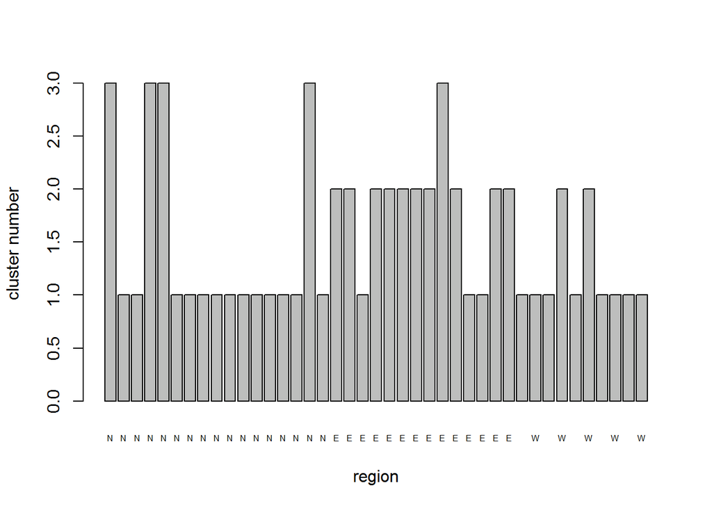

```r
NHCA_3clus_plt <-barplot(NHCA_fields1$cluster, names.arg=PCA1_cordata$region,  cex.names=0.5, xlab="region",
   ylab="cluster number")
```

#### Diagnosing the optimum number of clusters

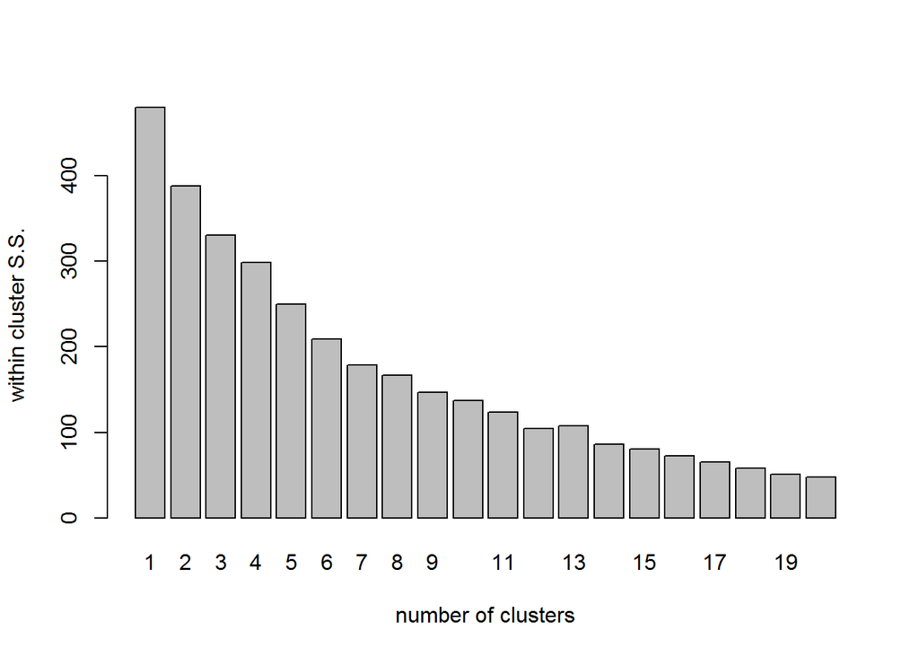

```r
wSS_fields1 <-(nrow(NHCA_data1)-1)*sum(apply(NHCA_data1[,3:14],2,var))
for (i in 2:20) wSS_fields1[i] <-sum(kmeans(NHCA_data1[,3:14], centers=i)$withinss)
clus_plot <-barplot(wSS_fields1, xlab="number of clusters",ylab="within cluster S.S.", names.arg=seq(1,20,1))
```

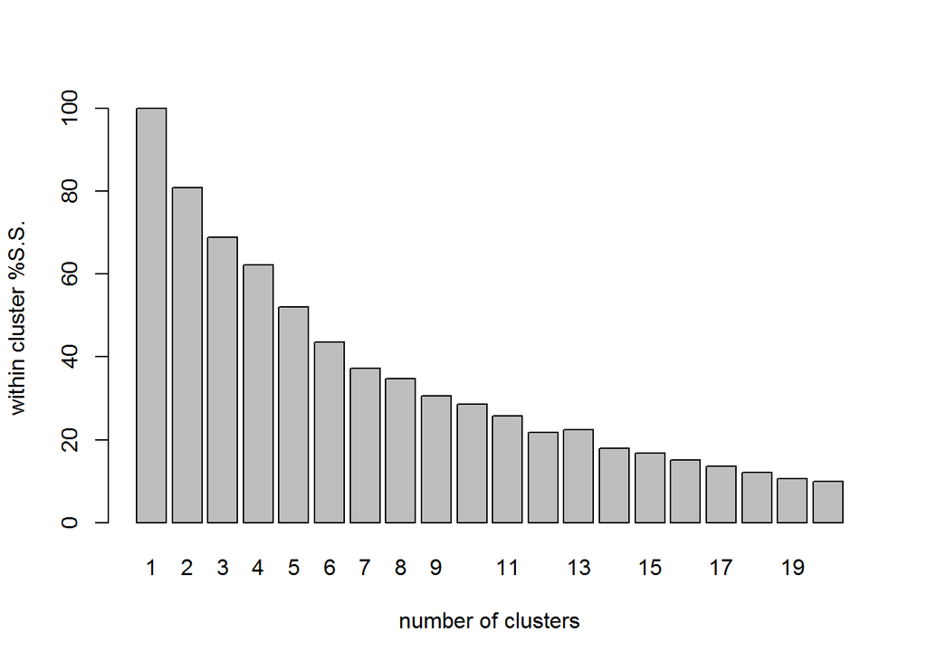

```r
wSS_fields1_pct <-(wSS_fields1/wSS_fields1[1])*100
clus_plot_pct <-barplot(wSS_fields1_pct, xlab="number of clusters",
                    ylab="within cluster %S.S.",names.arg=seq(1,20,1))
```

The *for*() loop cycles through the clustering procedure, extracts the within-cluster sum of squares and stores it in rows 2 to 20 of the data structure wSS_fields1 which was declared explicitly outside the loop. We get the total sum of squares among the objects in the calculation that declares wSS_fields1 using the *sum*() and *apply*() functions. The result is stored by implication in the first line of the new data structure. Note that this little piece of coding shows a feature of *for(*) loop writing that is often needed: **we do the first calculation outside the loop** and then write the loop so that it cycles from 2 to our maximum number of iterations. In this case that trick let’s us use the loop iteration index , $i$, to be the variable that sets the number of clusters we want to extract from the data each pass round the loop.

```r
# Cluster the fields into 7 groups
NHCA_fields2 <-kmeans(NHCA_data1[,3:14],7)
NHCA_fields2
```

```
## K-means clustering with 7 clusters of sizes 1, 20, 2, 4, 1, 6, 7
##
## Cluster means:
##         ST_L       St_G        Sn_L        Sn_G        Pm_L       Pm_G
## 1  0.1708408 -0.8087150  2.47049050  4.69870465  0.82089355 -0.4821244
## 2 -0.2557474 -0.1996096 -0.24850657 -0.30511069 -0.30099430 -0.1549928
## 3  0.6974930 -0.8087150  0.97653607 -0.30511069 -0.48362721 -0.4821244
## 4 -0.7639667 -0.1446527 -0.29332520 -0.30511069  2.25586639  2.4759804
## 5 -0.8824635 -0.8087150  4.46242973 -0.30511069  0.82089355 -0.4821244
## 6 -0.3558113 -0.8087150 -0.01943355  0.52885853 -0.04878696 -0.2501162
## 7  1.3746172  1.8082790 -0.37513699  0.05230469 -0.48362721 -0.4821244
##          Fu_L       Bo_L       SM_E         ES        SES         TA
## 1  0.05945873  1.0214250 -0.6927108  0.5187745  1.1648820 -0.3703586
## 2 -0.01889938 -0.4538377 -0.5405618 -0.4703639 -0.2855520  0.3575140
## 3 -1.68183270 -0.1683030  1.8431054  0.2244635  3.2679222 -0.3703586
## 4  1.14776588 -0.8821397 -0.6927108 -0.6573671  0.2033553 -0.2135458
## 5  0.05945873 -1.3580309  2.3502687 -0.6573671 -0.2914375 -0.3703586
## 6 -0.23075651  1.0214250  0.1525613  1.7292709  0.2247986 -0.3703586
## 7  0.05945873  1.0214250  1.0461346  0.1929696 -0.5514945 -0.3703586
##
## Clustering vector:
##  [1] 4 2 2 4 4 2 2 2 2 2 2 2 2 2 2 4 2 3 6 2 5 2 6 6 6 2 6 2 2 6 1 7 7 7 7
## [36] 7 3 2 7 7 2
##
## Within cluster sum of squares by cluster:
## [1]   0.00000 113.06750  10.91943  20.41663   0.00000  32.05380  22.83024
##  (between_SS / total_SS =  58.5 %)
##
## Available components:
##
## [1] "cluster"      "centers"      "totss"        "withinss"
## [5] "tot.withinss" "betweenss"    "size"         "iter"
## [9] "ifault"
```

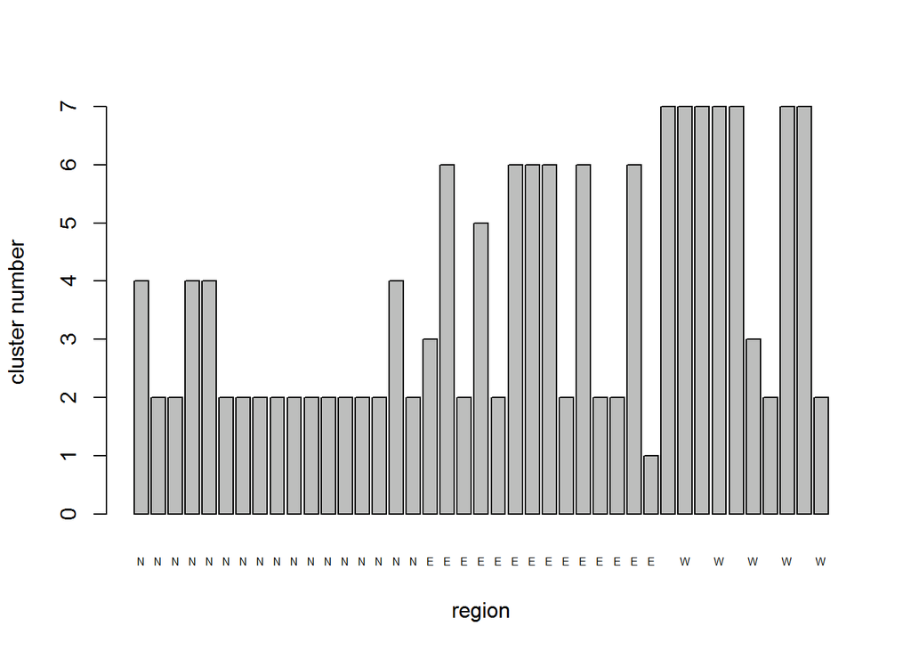

```r
NHCA_7clus_plt <-barplot(NHCA_fields2$cluster, names.arg=PCA1_cordata$region, cex.names=0.5,
                         xlab="region", ylab="cluster number")
```

Although the solution with 7 clusters has reduced the within-cluster S.S. to <50%, it has a couple of clusters that have only 1 or 2 members. This may reflect fields that are truly different from the rest of the sample in some important respect, but it might also be an artifact of the clustering process. It certainly suggests that we should look at the solution with only 6 clusters since we now have the hang of running the analysis.

```r
# Cluster the fields into 6 groups
NHCA_fields3 <-kmeans(NHCA_data1[,3:14],6)
NHCA_fields3
```

```
## K-means clustering with 6 clusters of sizes 3, 18, 3, 2, 10, 5
##
## Cluster means:
##         ST_L       St_G       Sn_L        Sn_G        Pm_L        Pm_G
## 1 -0.3558113 -0.8087150  1.1425310  3.03076620 -0.04878696 -0.48212440
## 2 -0.4465125 -0.1929944 -0.2905586 -0.30511069 -0.22272306 -0.01037435
## 3 -0.9175736 -0.1675514 -0.4510204 -0.30511069  2.82115871  2.81239232
## 4 -0.6191374 -0.8087150  3.4664601 -0.30511069  0.16863317 -0.48212440
## 5  1.2241451  1.2063704 -0.2186275 -0.05491992 -0.48362721 -0.48212440
## 6  0.1708408 -0.8087150 -0.3182244 -0.30511069  0.03818110 -0.20371453
##          Fu_L       Bo_L       SM_E          ES        SES         TA
## 1  0.05945873  1.0214250 -0.3546019  0.98283793  0.4362660 -0.3703586
## 2  0.14652330 -0.7235094 -0.6363593 -0.50672106 -0.2530372  0.3745021
## 3  1.04619054 -0.8821397 -0.6927108 -0.65736713  0.2660883 -0.1612749
## 4 -0.81118698 -1.3580309  1.8431054 -0.54713830  1.4427324 -0.3703586
## 5 -0.11467041  1.0214250  0.7273463  0.04071208 -0.5001675 -0.2553626
## 6 -0.63705784  1.0214250  0.7273463  1.76634449  0.9127635 -0.3703586
##
## Clustering vector:
##  [1] 2 2 2 3 3 2 2 2 2 2 2 2 2 2 2 3 2 4 6 2 4 2 6 6 1 2 6 5 5 1 1 5 5 5 5
## [36] 5 6 2 5 5 5
##
## Within cluster sum of squares by cluster:
## [1] 10.53387 94.79853 14.43222 11.04295 45.04325 36.40606
##  (between_SS / total_SS =  55.8 %)
##
## Available components:
##
## [1] "cluster"      "centers"      "totss"        "withinss"
## [5] "tot.withinss" "betweenss"    "size"         "iter"
## [9] "ifault"
```

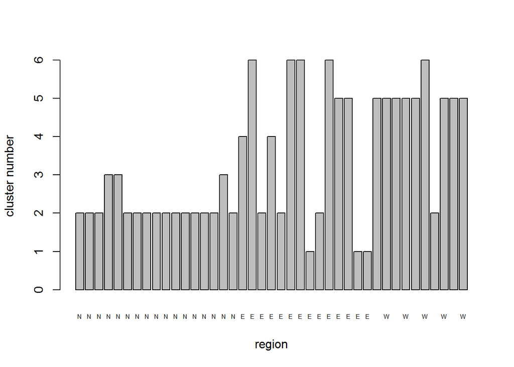

```r
NHCA_6clus_plt <-barplot(NHCA_fields3$cluster, names.arg=PCA1_cordata$region, cex.names=0.5,
                         xlab="region", ylab="cluster number")
```

Sacrificing some of the within-cluster S.S. by moving from 7 to 6 clusters didn’t really gain us anything useful; we still have a couple of fields that apparently do not belong to any of the larger clusters. Some general results from the analysis are apparent, however. The majority of fields from the West remain clustered together, while the majority of fields from the North form a second relatively stable cluster. The remaining fields from these regions and most of those in the East tend to change cluster identity as the number of clusters changes, suggesting that they do not have as coherent a pattern of diseases as those from the other regions.

A graphical representation of how coherent the different clusters are, would be helpful in interpreting the results of the cluster analysis. We will look at how ordination can be combined with cluster analysis to achieve this, but before doing that, we will look at hierarchical clustering.

### Hierarchical Cluster Analysis

As we indicated in the introduction to this section the aim in hierarchical clustering is to form clusters of objects by starting with each object in a cluster of its own and iteratively linking them together according to a clustering algorithm applied to a distance (or similarity matrix) for the objects. We already saw that a distance matrix is the basis for a PCO. We will use the same type of data structure here to examine how the individual fields cluster.

The **complete** (or farthest neighbor) algorithm does the same thing except that it selects the pair of existing clusters whose **least similar members have the highest similarity** among all possible pairwise comparisons. The result is that single clustering tends to produce *long* diffuse clusters which may contain rather dissimilar members linked by a long series of pairs of somewhat similar neighbors. In contrast complete clustering tends to produce a large number of small, compact clusters with relatively large inter-cluster differences.

It is important to note that with HCA both the choice of distance metric used to construct the distance matrix **and** the clustering algorithm will affect the results of the clustering exercise. The standard approach to displaying the results of HCA is to draw a tree or dendrogram. The base stats package provides some fairly nice tree drawing tools and some additional tools for exploring the structure of the tree or highlighting groupings. The following block of code, does four HCAs on the disease data, first a pair based on a Euclidean distance matrix calculated from the scaled data and then a pair with the data converted to simple presence/absence of each disease in each field and translated into a binary distance matrix. In each pair we first apply the complete joining algorithm and then the single joining algorithm. We also illustrate the use of the *cutree*() function to cut each tree into 7 groups and the *rect.hclust*() function to draw boxes around the branches of the trees identified by *cutree*().

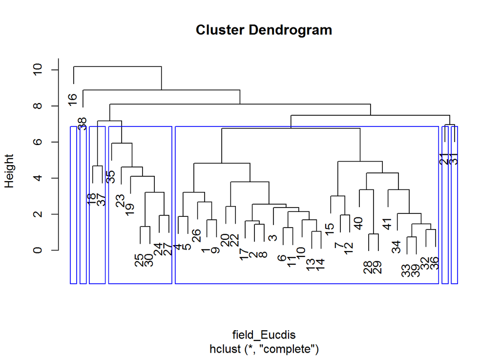

```r
#Hierachical cluster analysis: Euclidean distance matrix, furthest neighbor clustering
field_Eucdis <-dist(NHCA_data1[,3:14], method="euclidean")
HCA_field1 <-hclust(field_Eucdis, method="complete")
dend_field1 <-plot(HCA_field1)
field_hgroups1 <-cutree(HCA_field1, k=7)
rect.hclust(HCA_field1, k=7, border="blue")
```

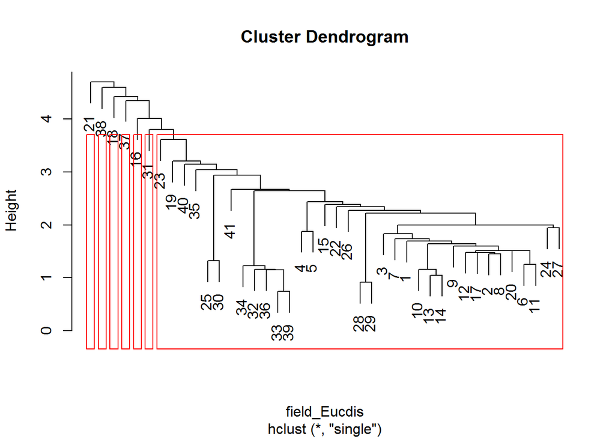

```r
#Euclidean distance matrix, nearest neighbor clustering
HCA_field2 <-hclust(field_Eucdis, method="single")
dend_field2 <-plot(HCA_field2)
field_hgroups2 <-cutree(HCA_field2, k=7)
rect.hclust(HCA_field2, k=7, border="red")
```

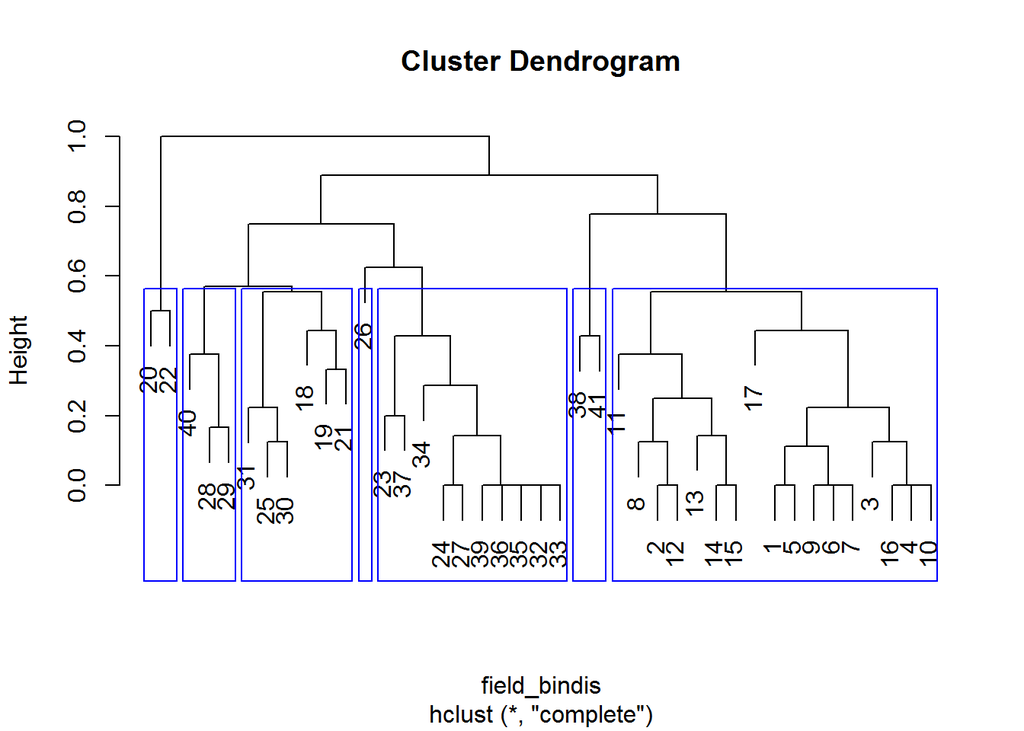

```r
# How do the results look if we use binary data?
# Binary distance matrix, furthest neighbor clustering

HCA_data2 <-data.frame(PCA1_cordata[,1:2],(PCA1_cordata[,3:14]>0)*1)
field_bindis <-dist(HCA_data2[,3:14], method="binary")
HCA_field3 <-hclust(field_bindis, method="complete")
dend_field3 <-plot(HCA_field3)
field_hgroups3 <-cutree(HCA_field3, k=7)
rect.hclust(HCA_field3, k=7, border="blue")
```

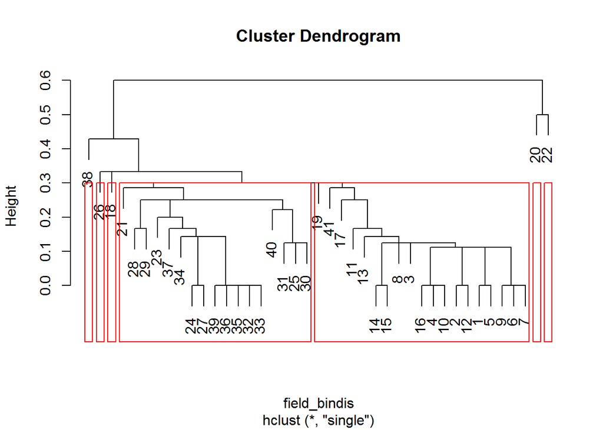

```r
#Binary distance matrix, nearest neighbor clustering
HCA_field4 <-hclust(field_bindis, method="single")
dend_field4 <-plot(HCA_field4)
field_hgroups4 <-cutree(HCA_field4, k=7)
rect.hclust(HCA_field4, k=7, border="red")
```

We have only touched on the basic approaches for HCA even among the options offered in the base stats package. In addition to the options available in the base package remember there is a wide range of other packages available that allow distances to be calculated using other metrics and clustering to be carried out with many different algorithms. Some of these packages are written with specific purposes in mind, others are more general. Rather than explore a subset of these options, in the limited time of the workshop we are going to stay with analyses that can be performed with the base package and move on to look at how we can combine ordination and cluster analyses to get good visualizations of clusters of objects.